# Data Visualization with R

### Changing the Text of Tick Labels

Let us consider the scatterplot showing the relationship between ink and solvent percentage in cylinder banding process in rotogravure printing, stored in `pl_2` object:

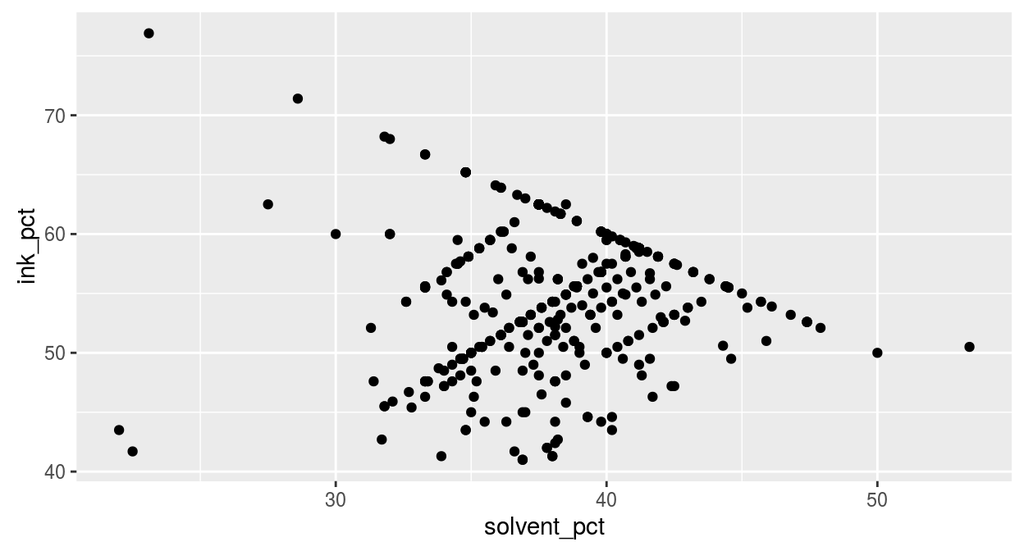

```r
pl_2
```

To change the text of ticks marks in continuous axes, set `breaks` and `labels` in `scale_y_continuous` function:

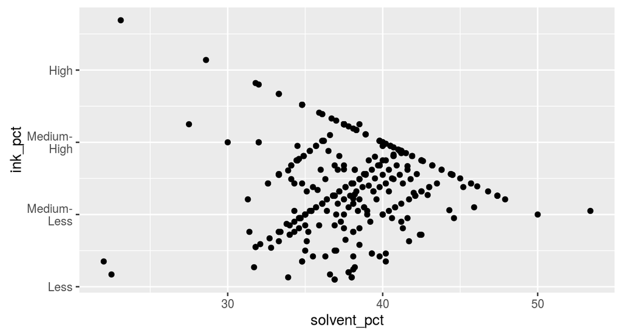

```r
pl_2 +
  scale_y_continuous(breaks=c(40, 50, 60, 70), labels=c("Less", "Medium-\nLess", "Medium-\nHigh", "High"))
```

Pay attention to `"\n"` character, which tells `ggplot()` to put a line break.

Let us consider the example described in *Axis scale transformations* paragraph, which analyze the relationship between body and brain weight of 15 species of animals, stored in `pl_3` object:

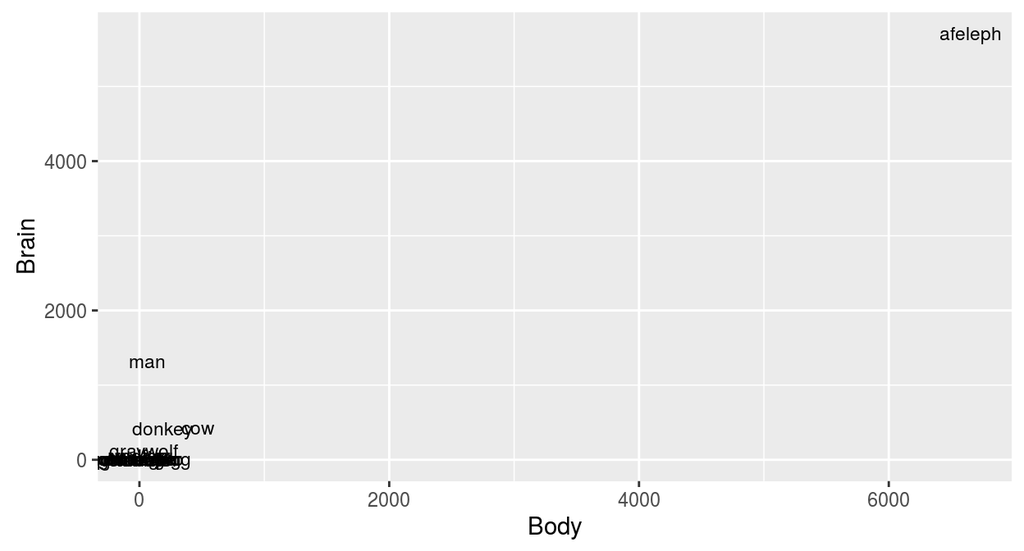

```r
pl_3
```

We applied a logarithmic transformation to the axis:

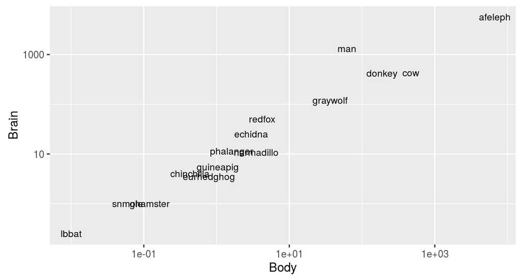

```r
pl_3 +
  scale_x_log10()+
  scale_y_log10()
```

With a log axis, a given visual distance represents a constant proportional change; for example, each centimeter on the y-axis might represent a multiplication of the quantity by 10. In contrast, with a linear axis, a given visual distance represents a constant quantity change; each centimeter might represent adding 10 to the quantity.

`ggplot2` will try to make good decisions about where to place the tick marks, but if you don’t like them, you can change them by specifying breaks and, optionally, labels . In the example here, the automatically generated tick marks are spaced farther apart than is ideal. For the y-axis tick marks, we can get a vector of every power of 10 from $10^{0}$ to $10^{3}$ like this:

`10^(0:3)`

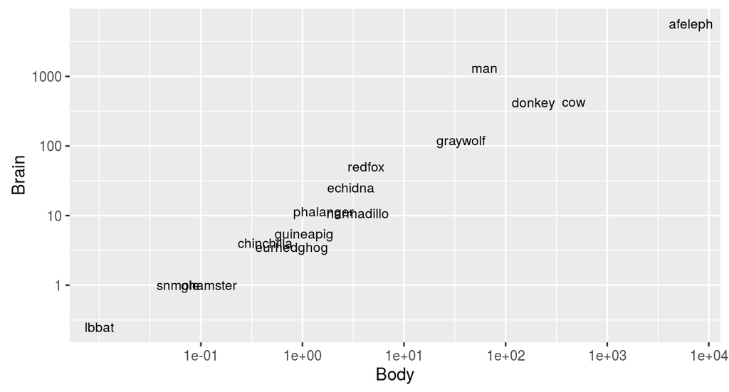

```r
pl_3 +
  scale_x_log10(breaks=10^(-1:5)) +
  scale_y_log10(breaks=10^(0:3))
```

To instead use exponential notation for the break labels, use the `trans_format()` function, from the `scales` package:.

Supposing `scales` is already installed, it must be loaded:

```r
require(scales)
```

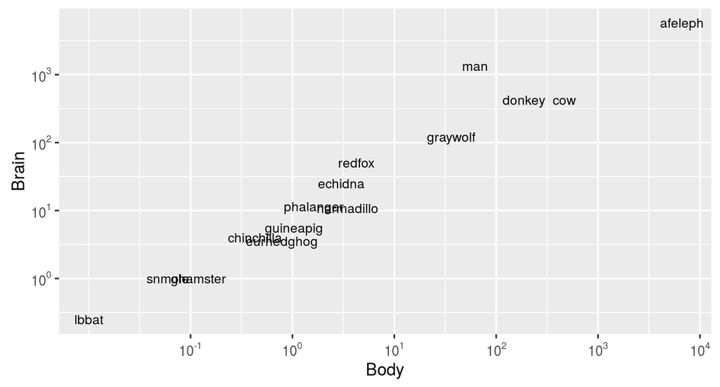

```r
pl_3 +
  scale_x_log10(breaks=10^(-1:5), labels=trans_format("log10", math_format(10^.x))) +
  scale_y_log10(breaks=10^(0:3), labels=trans_format("log10", math_format(10^.x)))
```

`trans_format()` function set a format to labels after a transformation. The transformation is “log10” and the format is specified by the function `math_format()` (of `scales` package), which define the arbitrary expression to use for the label.

Talking about the plot in which scales have been transformed by natural log and $log_{2}$:

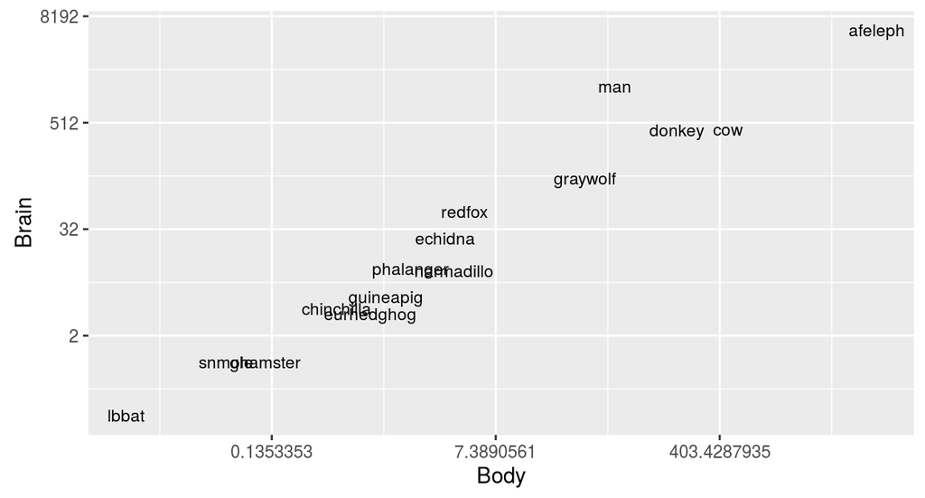

```r
pl_3 +
  scale_x_continuous(trans = log_trans()) +
  scale_y_continuous(trans = log2_trans())
```

The labels can be modified in this way:

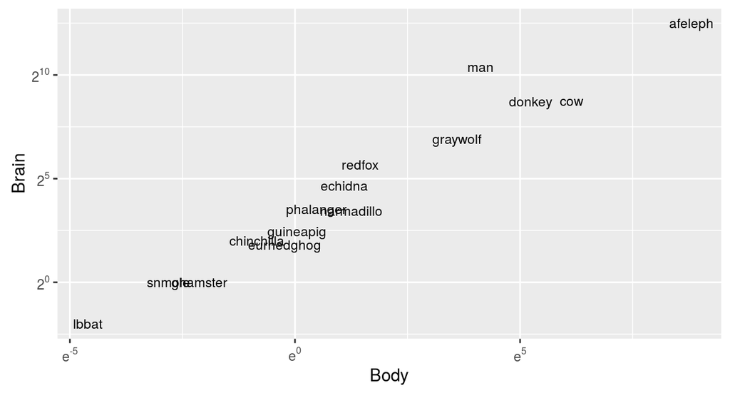

```r
pl_3 +
  scale_x_continuous(trans = log_trans(), breaks = trans_breaks("log", function(x) exp(x)),
    labels = trans_format("log", math_format(e^.x))) +
  scale_y_continuous(trans = log2_trans(), breaks = trans_breaks("log2", function(x) 2^x),
    labels = trans_format("log2", math_format(2^.x)))
```

`trans_breaks()` function of `scales` package define the breaks according to the transformation applied.

Let us go back to boxplot showing the distribution of `ink_pct` by `press_type` in `bands` dataset.  
To change the text of ticks marks in discrete axes, set the `labels` argument in `scale_x_discrete()` function.

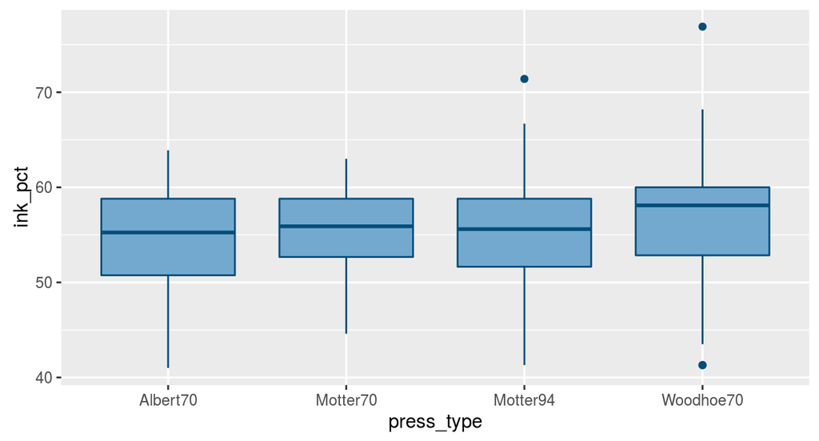

```r
pl_1 +
  scale_x_discrete(labels=c("Albert70", "Motter70", "Motter94", "Woodhoe70"))
```

### Changing the Appearance of Tick Labels

Text properties like rotation, size, style (bold/italic/normal), and the font family (such as Times or Helvetica) can be set with `element_text()` theme function:

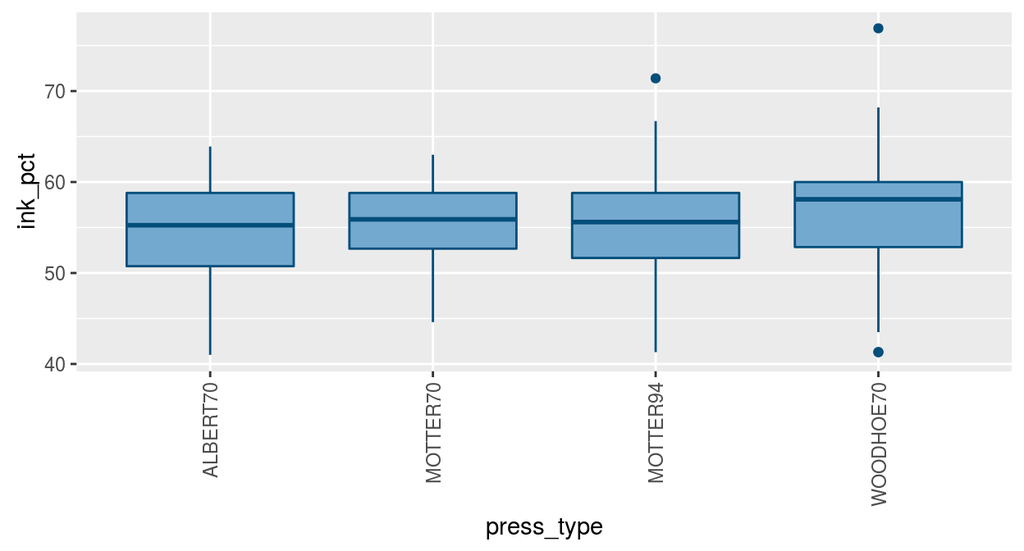

```r
# To rotate the text 90 degrees counterclockwise
pl_1 +
  theme(axis.text.x = element_text(angle=90, hjust=1, vjust=0.5))
```

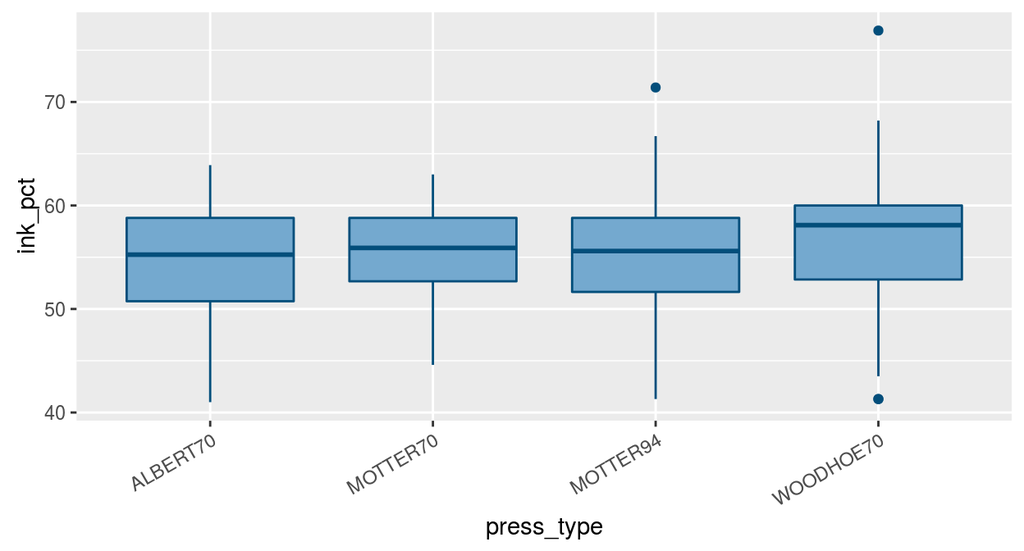

```r
# Rotating the text 30 degrees
pl_1 +
  theme(axis.text.x = element_text(angle=30, hjust=1, vjust=1))
```

The `angle` setting specifies the text rotation and the `hjust` and `vjust` settings specify the horizontal alignment (left/center/right) and vertical alignment (top/middle/bottom).

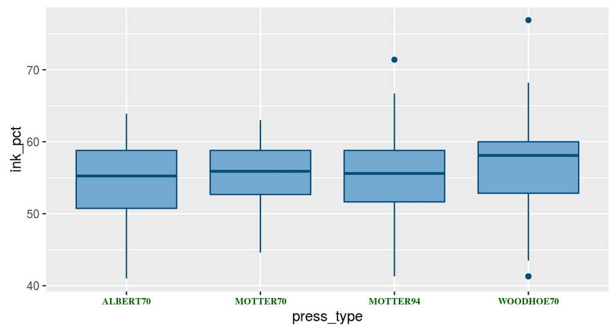

```r
pl_1 +
  theme(axis.text.x = element_text(family="Times", face="bold", colour="darkgreen", size=rel(0.8)))
```

The `family` setting specifies the font family, `face` the font face, `colour` the text colour and `size` the text size. In this example, the size is set to `rel(0.8)`, which means that it is 0.8 times the size of the base font size for the theme.

### Changing the Appearance of Tick marks

The appearance of tick marks can be changed by `element_line()` theme function.

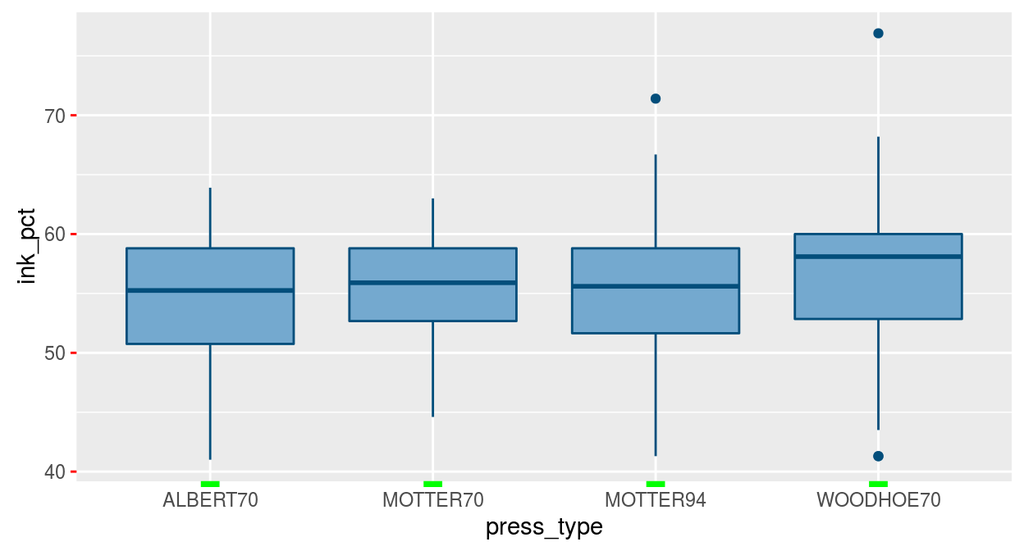

```r
pl_1 +
  theme(axis.ticks.x = element_line(colour="green", size=4), axis.ticks.y=element_line(colour="red"))
```

In particular, `colour` setting specifies the line colour and `size` the line size.

### Changing the Text of Axis Labels

By default the graphs will just use the column names from the data frame as axis labels. This might be fine for exploring data, but for presenting it, you may want more descriptive axis labels.

`ggplot2` provides these three equivalent ways to change the axis labels:

```r
pl_1 +
  xlab("Pressure type") +
  ylab("Ink percentage")
pl_1 +
  labs(x = "Pressure type", y = "Ink percentage")
pl_1 +
  scale_y_continuous(name="Ink percentage") +
  scale_x_discrete(name="Pressure type")
```

Which produces the same results:

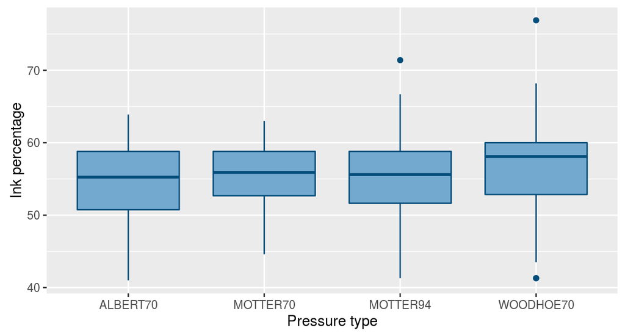

Using `scale_y_continuous()` may look a bit awkward, but it can be useful if you’re also setting other properties of the scale, such as the tick mark placement, range, and so on.

### Removing Axis Labels

Sometimes axis labels are redundant or obvious from the context, and don’t need to be displayed.

You can set x label to an empty string:

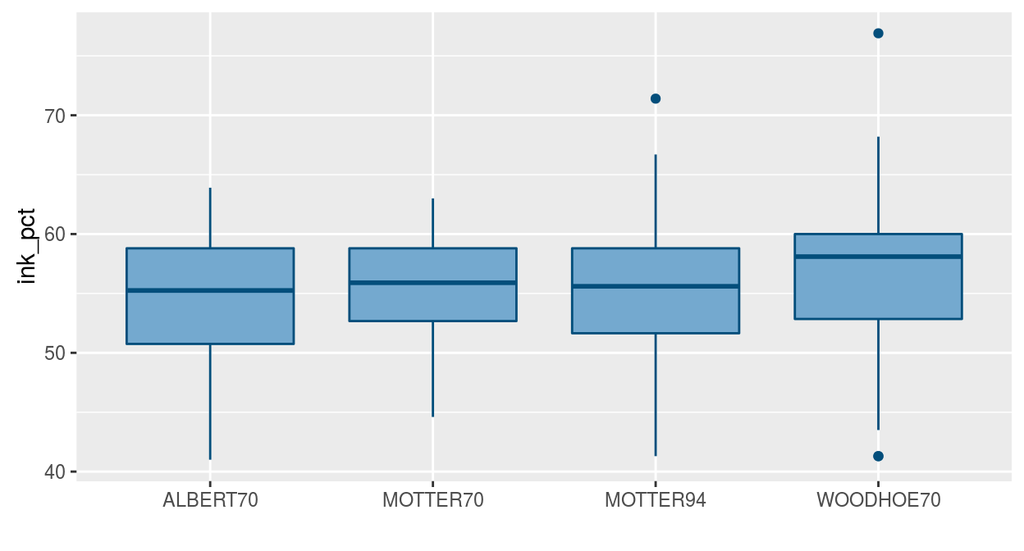

```r
pl_1 +
  xlab("")
```

or you can use `theme()` function to set `axis.title.x=element_blank()`:

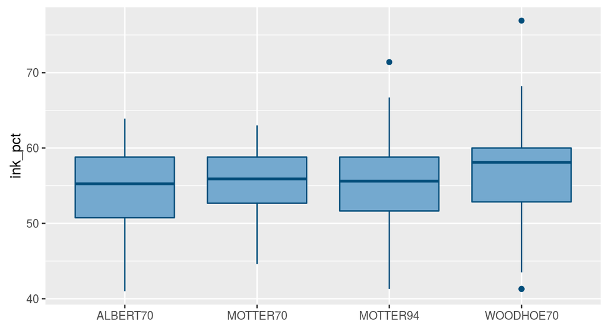

```r
pl_1 +
  theme(axis.title.x=element_blank())
```

The difference between the two ways is that `theme()` function doesn’t change axis name. The text is not displayed and no space is reserved for it. When you set the label to “” in `xlab()` function, the name of the scale is changed and the (empty) text is displayed.

### Changing the appearance of axis labels

`axis.title.x`, `axis.title.y` and `axis.title` arguments of `theme()` function controls the label of x, y or both axis.

The reference function is `element_text()` and works at the same way as we saw in *Changing the Appearance of Tick Labels* paragraph.

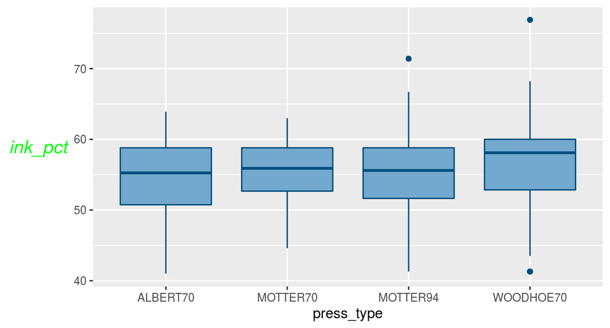

```r
pl_1 +
  theme(axis.title.y=element_text(angle=0, face="italic", size=14, colour = "green"))
```

## Using Dates on an Axis

```r
econ <- subset(economics, date >= as.Date("1992-05-01") & date < as.Date("1993-06-01"))
```

Suppose we want to generate the time series plot of personal savings rate:

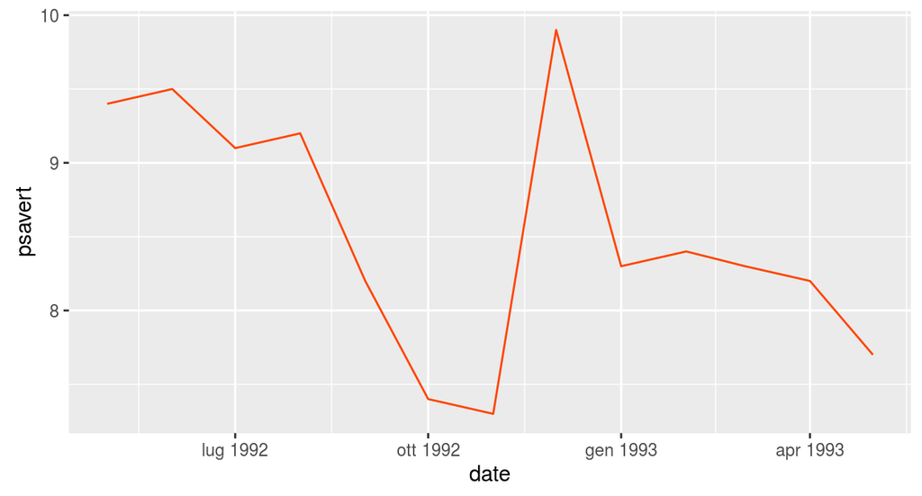

```r
pl_4 <- ggplot(econ, aes(x=date, y=psavert)) +
  geom_line(colour = "orangered")
pl_4
```

`scale_x_date()` function handle with date scales, the argument `date_breaks` specifies the distance between breaks.

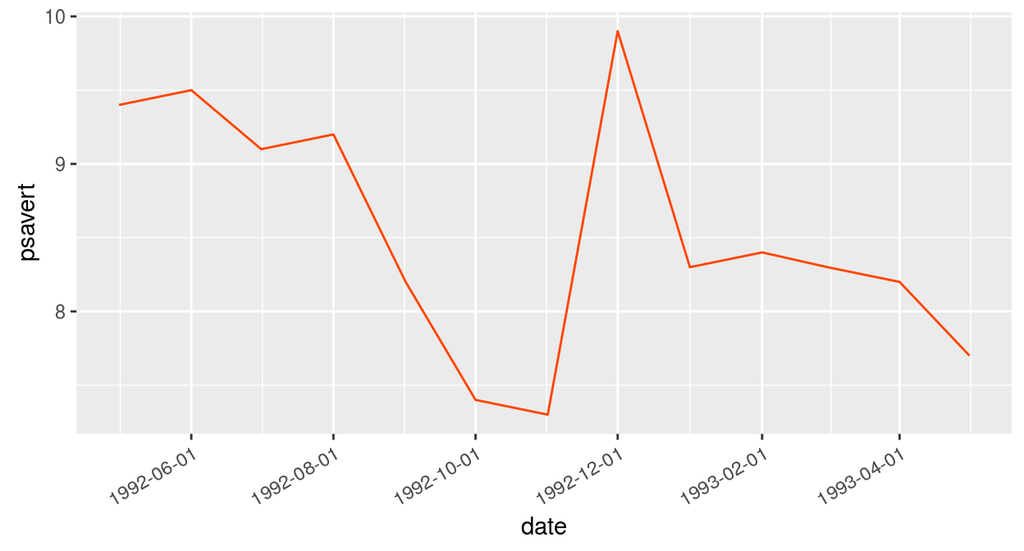

```r
# Use breaks, and rotate text labels
pl_4 +
  scale_x_date(date_breaks= "2 month") +
  theme(axis.text.x = element_text(angle=30, hjust=1))
```

Notice that the formatting of the breaks changed. You can specify the formatting by using the `date_format()` function from the `scales` package as `label` value:

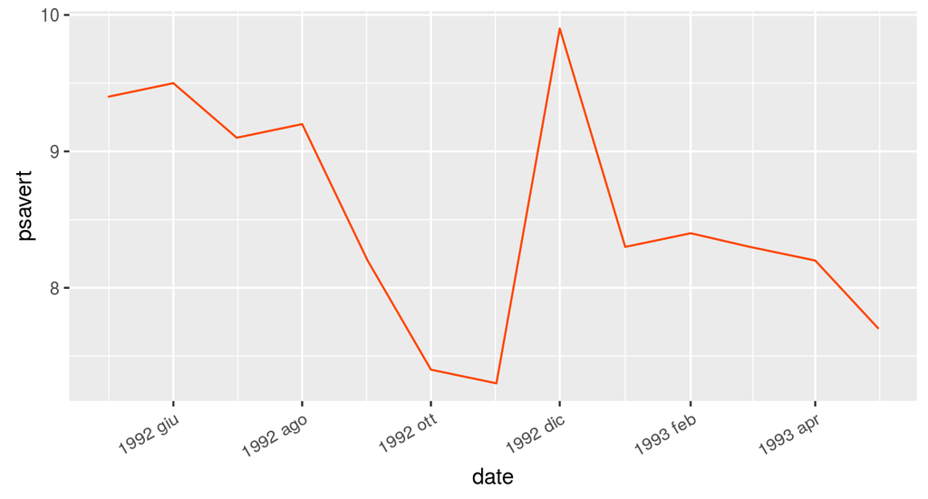

```r
pl_4 +
  scale_x_date(date_breaks= "2 month", labels=date_format("%Y %b")) +
  theme(axis.text.x = element_text(angle=30, hjust=1))
```

The format specified is `"%Y %b"`, which results like `"1992 Jun"`.

The format specified is to be put in a string that is passed to `date_format()`, and the format specifiers will be replaced with the appropriate values. For example, if you use `"%B %d, %Y"`, it will result in labels like `"June 01, 1992"`.

The following table lists the most important date-time format:

| Option | Description |
| --- | --- |
| %Y | Year with century (2012) |
| %y | Year without century (12) |
| %m | Month as a decimal number (08) |
| %b | Abbreviated month name in current locale (Aug) |
| %B | Full month name in current locale (August) |
| %d | Day of month as a decimal number (04) |
| %U | Week of the year as a decimal number, with Sunday as the first day of the week (00–53) |
| %W | Week of the year as a decimal number, with Monday as the first day of the week (00–53) |
| %w | Day of week (0–6, Sunday is 0) |
| %a | Abbreviated weekday name (Thu) |
| %A | Full weekday name (Thursday) |